# COVID-19 Project

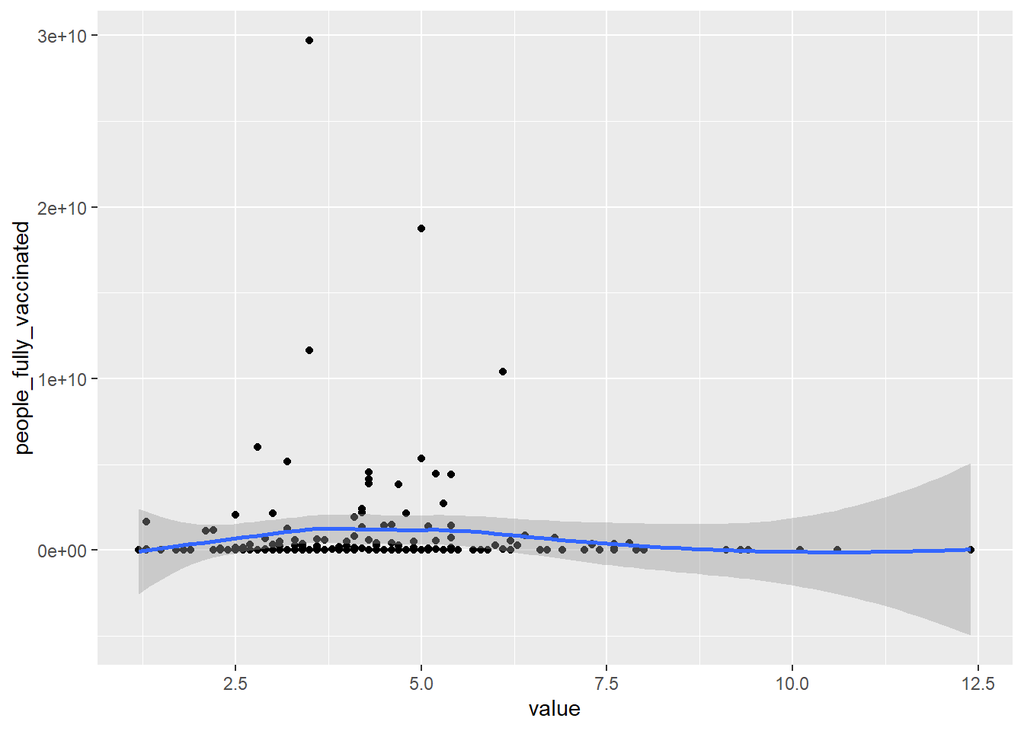

```r
ggplot(covid_edu_after,mapping = aes(x=value,y=people_fully_vaccinated))+geom_point()+geom_smooth()
```

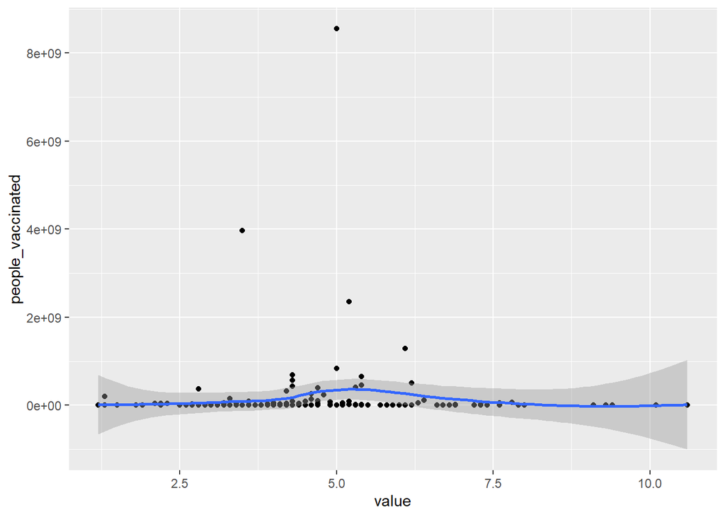

```r
ggplot(covid_edu_before,mapping = aes(x=value,y=people_vaccinated))+geom_point()+geom_smooth()
```

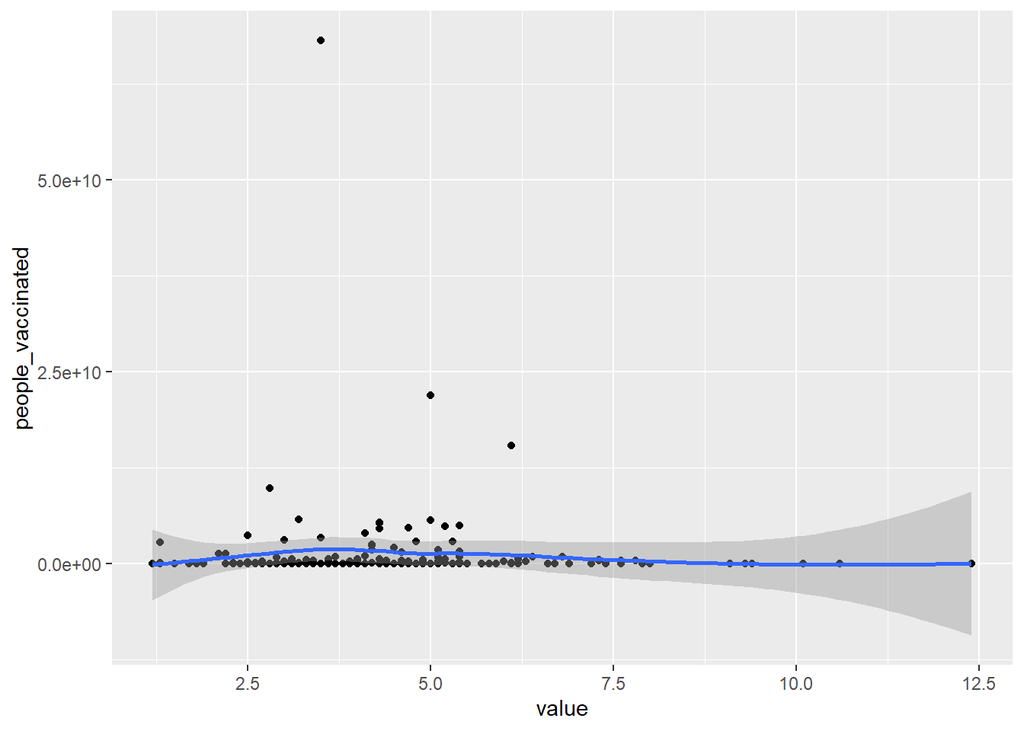

```r
ggplot(covid_edu_after,mapping = aes(x=value,y=people_vaccinated))+geom_point()+geom_smooth()
```

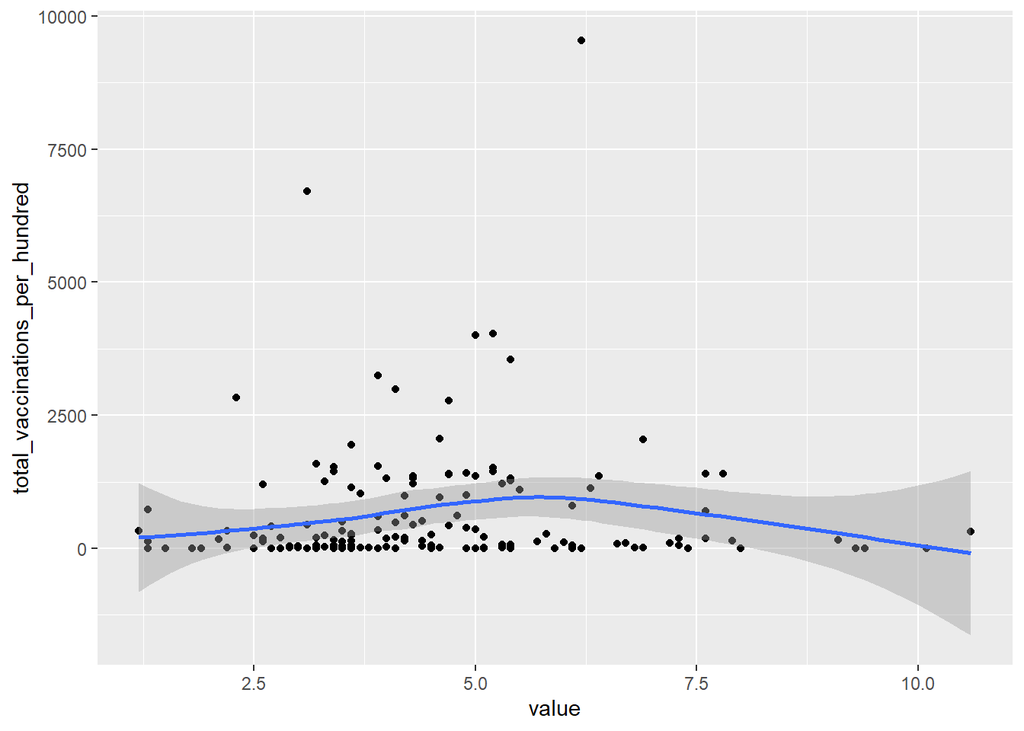

```r
ggplot(covid_edu_before,mapping = aes(x=value,y=total_vaccinations_per_hundred))+geom_point()+geom_smooth()
```

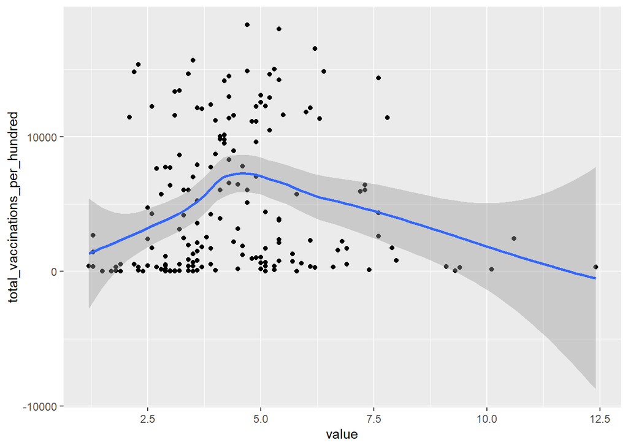

```r
ggplot(covid_edu_after,mapping = aes(x=value,y=total_vaccinations_per_hundred))+geom_point()+geom_smooth()
```

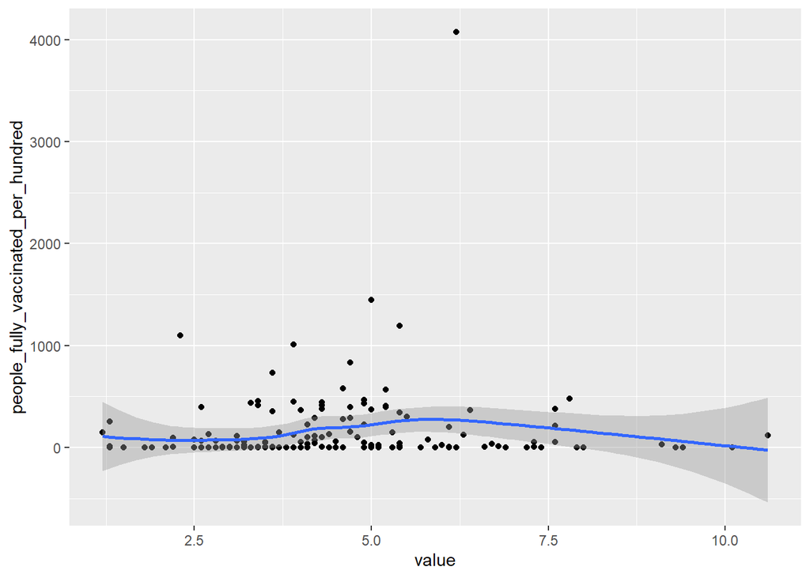

```r
ggplot(covid_edu_before,mapping = aes(x=value,y=people_fully_vaccinated_per_hundred))+geom_point()+geom_smooth()
```

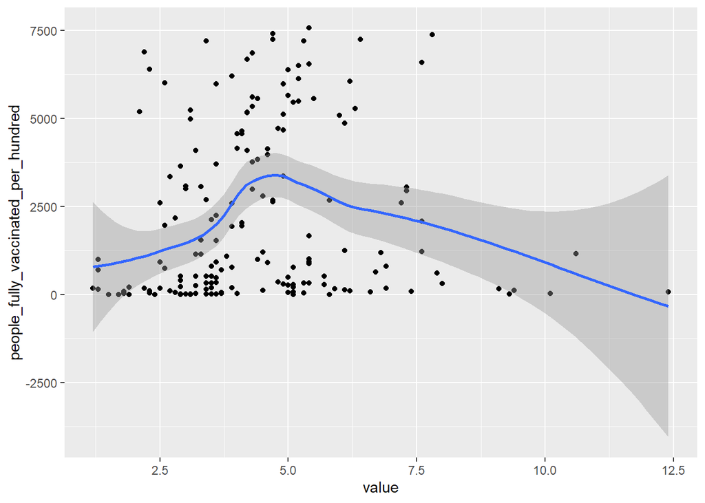

```r
ggplot(covid_edu_after,mapping = aes(x=value,y=people_fully_vaccinated_per_hundred))+geom_point()+geom_smooth()
```

From total vaccinated per hundred and people fully vaccinated per hundred, we can see a more spread graph in period after Sept 01 than the period before May 01. It illustrates the country have relative higher education expenditure would have better performance in vaccination. However, we can see there are a few countries which have high education expenditure would have limited vaccination. Does that means the region influence the vaccinations? We pick total_vaccinations_per_hundred and people_fully_vaccinated_per_hundred to construct the new graph because it is more clear to analyze the difference between the different time spot.

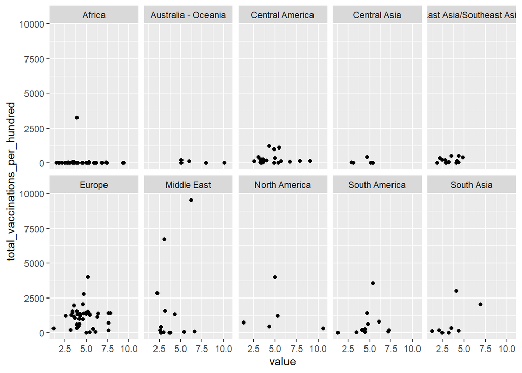

```r
ggplot(covid_edu_before,mapping = aes(x=value,y=total_vaccinations_per_hundred))+geom_point()+
  facet_wrap(~region, nrow = 2)
```

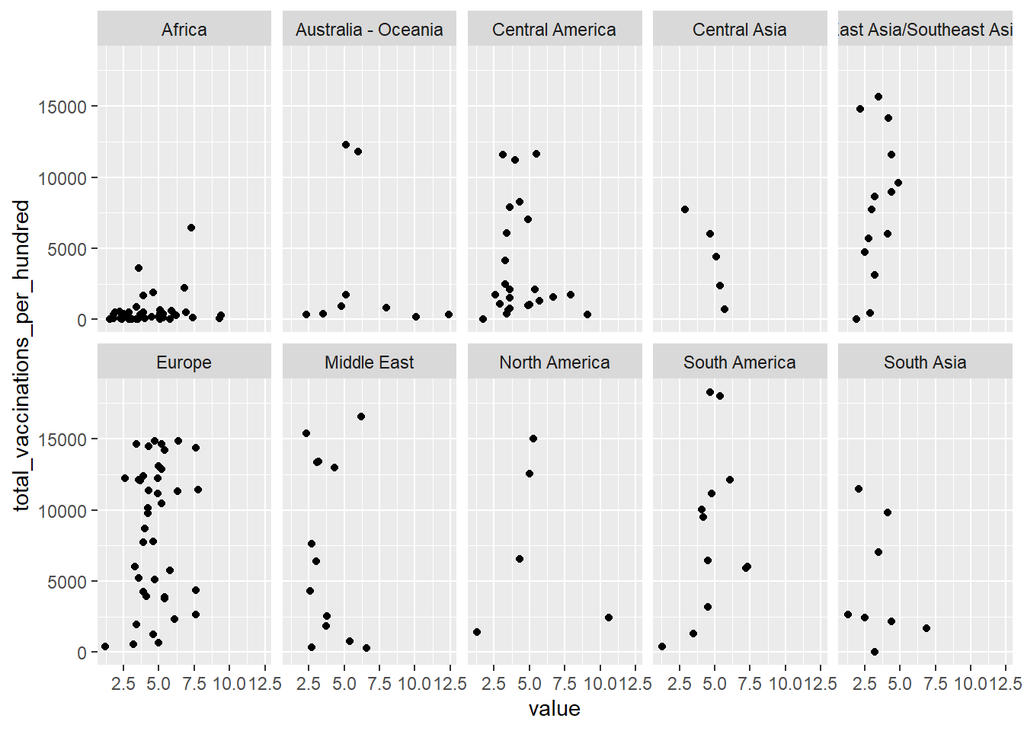

```r
ggplot(covid_edu_after,mapping = aes(x=value,y=total_vaccinations_per_hundred))+geom_point()+
  facet_wrap(~region, nrow = 2)
```

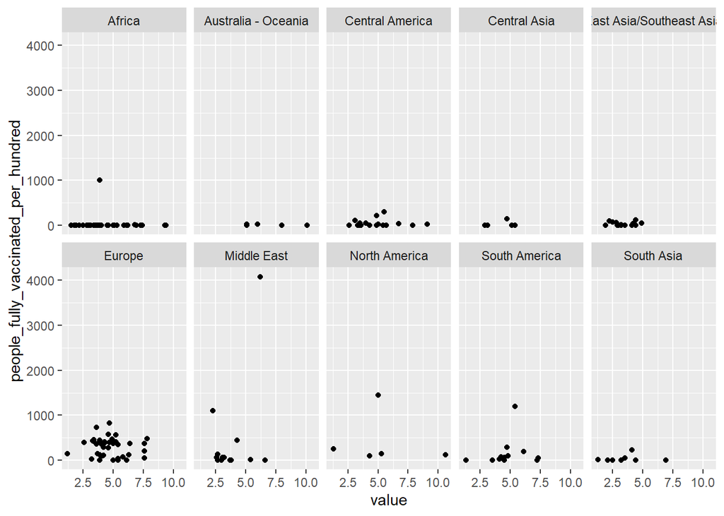

```r
ggplot(covid_edu_before,mapping = aes(x=value,y=people_fully_vaccinated_per_hundred))+geom_point()+
  facet_wrap(~region, nrow = 2)
```

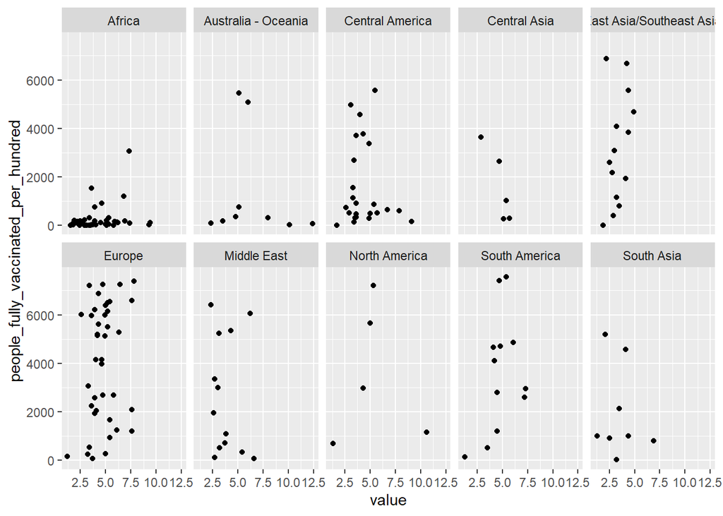

```r
ggplot(covid_edu_after,mapping = aes(x=value,y=people_fully_vaccinated_per_hundred))+geom_point()+
  facet_wrap(~region, nrow = 2)
```

**GINI coefficient and COVID-19**